# BIOS6611-Homework7-Randy-20191024

Randy

10/24/2019

#### Question1a

A study based on 1,500 observations using the SOC identified a median LOS of 9 days. For both hospitals, test if their median LOS is significantly different from the historic median of 9 days using a function in R (e.g., wilcox.exact, binom.test, SIGN.test, etc.) and interpret your results.

```r
library(exactRankTests)
library(BSDA)
NewLOS<-c(3, 3, 4, 5, 5, 5, 6, 7, 7, 8, 9, 15)
SOCLOS<-c(6, 7, 7, 7, 8, 8, 8, 9, 9, 10, 10, 11, 13, 13, 15)
SIGN.test(NewLOS, m=9)
```

```
##
##  One-sample Sign-Test
##
## data:  NewLOS
## s = 1, p-value = 0.01172
## alternative hypothesis: true median is not equal to 9
## 95 percent confidence interval:
##  4.106364 7.893636
## sample estimates:
## median of x
##         5.5
##
## Achieved and Interpolated Confidence Intervals:
##
##                   Conf.Level L.E.pt U.E.pt
## Lower Achieved CI     0.8540 5.0000 7.0000
## Interpolated CI       0.9500 4.1064 7.8936
## Upper Achieved CI     0.9614 4.0000 8.0000
```

```r
SIGN.test(SOCLOS, m=9)
```

```
##
##  One-sample Sign-Test
##
## data:  SOCLOS
## s = 6, p-value = 1
## alternative hypothesis: true median is not equal to 9
## 95 percent confidence interval:
##   7.178168 10.821832
## sample estimates:
## median of x
##           9
##
## Achieved and Interpolated Confidence Intervals:
##
##                   Conf.Level L.E.pt  U.E.pt
## Lower Achieved CI     0.8815 8.0000 10.0000
## Interpolated CI       0.9500 7.1782 10.8218
## Upper Achieved CI     0.9648 7.0000 11.0000
```

For the New LOS median is significantly different from the historic median of 9 days with Sign test; however, the SOC LOS median is the same as the historic median of 9 days with Sign test.

#### Question1b

reate a 2x1 panel figure showing histograms of the LOS for Cauchy General and Skellam Memorial that have a range from 0 to 16 for their x-axis, have bins of width 2 (e.g., “breaks” at 0, 2, 4, 6, …, 14, and 16 in the base R hist function), and informative titles and labels. [Hint: One option to creating a panel figure is to use par( mfrow=c( number rows, number columns ) ).]

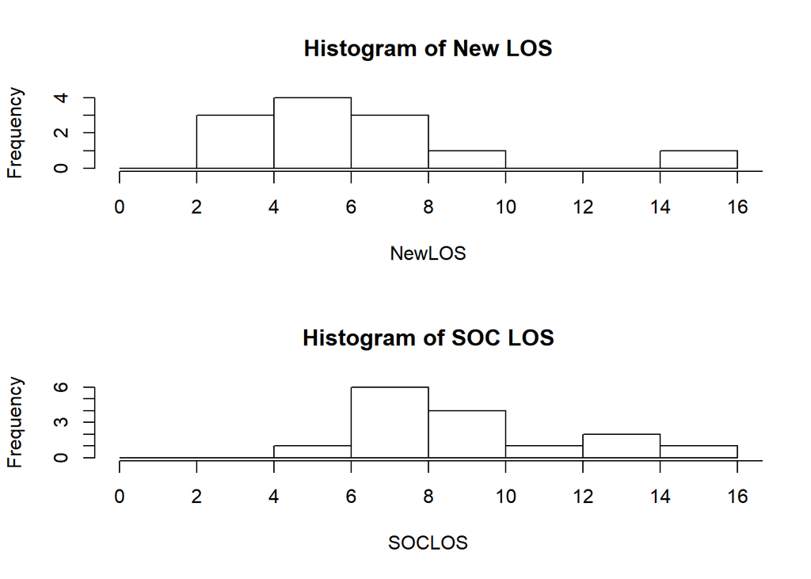

```r
par(mfrow=c(2, 1))
hist(NewLOS, main="Histogram of New LOS", xlim=c(0, 16), xaxt = 'n', breaks=c(seq(0, 16, by=2)))
axis(1, at = 2*(0:20))
hist(SOCLOS, main="Histogram of SOC LOS", xlim=c(0, 16), xaxt = 'n',  breaks=c(seq(0, 16, by=2)))
axis(1, at = 2*(0:20))
```

#### Question1c

Carry out a nonparametric procedure for testing the hypothesis that lengths of stay are comparable in the two hospitals by using a function in R (e.g., wilcox.exact, binom.test, SIGN.test, etc.). For your interpretation, if appropriate, reference your histogram from part (b) for discussion of the shape of the two groups.

```r
wilcox.test(NewLOS, SOCLOS, alternative = "two.sided", paired = FALSE, exact = F, correct = F)
```

```
##
##  Wilcoxon rank sum test
##
## data:  NewLOS and SOCLOS
## W = 33.5, p-value = 0.005517
## alternative hypothesis: true location shift is not equal to 0
```

```r
wilcox.exact(x=NewLOS, y=SOCLOS, alternative = "two.sided", paired = FALSE, exact = F, correct = T)
```

[output not shown]

According to the test, the p-value is less than 0.05 so we reject the null hyothesis that the two sample have the same distribution. According to the graphs, we can see the New’s distribution is left shifted than the SOC, which is consistant with the results.

#### Question2

After correction, which SNPs show statistically significant effects?

```r
SNPpvalue <- c(0.04,0.100,0.400,0.550,0.340,0.620,0.001,0.010,0.800,0.005)
Number <- 1:length(SNPpvalue)
SNPpvalueAdj <- p.adjust(SNPpvalue, method="BH", n=length(SNPpvalue))
SNPAdj<-as.data.frame(cbind(Number, SNPpvalue, SNPpvalueAdj))
SNPAdj[SNPpvalue<=0.05,]
```

```
##    Number SNPpvalue SNPpvalueAdj
## 1       1     0.040   0.10000000
## 7       7     0.001   0.01000000
## 8       8     0.010   0.03333333
## 10     10     0.005   0.02500000
```

```r
SNPAdj[SNPpvalueAdj<=0.05,]
```

```
##    Number SNPpvalue SNPpvalueAdj
## 7       7     0.001   0.01000000
## 8       8     0.010   0.03333333
## 10     10     0.005   0.02500000
```

#### Question3a

Assume that the variances across the groups are equal and test the hypothesis that there is an overall mean difference in bronchial reactivity among the three lung-function groups.

```r
library(tidyverse)
FEVFVC <- data.frame(Group = c( rep("A", 5), rep("B", 12), rep("C", 5)), Volume = c(20.8, 4.1, 30.0, 24.7, 13.8, 7.5, 7.5, 11.9, 4.5, 3.1, 8.0, 4.7, 28.1, 10.3, 10.0, 5.1, 2.2, 9.2, 2.0, 2.5, 6.1, 7.5))
FEVFVCaov <- aov(Volume~Group, data = FEVFVC)
summary(FEVFVCaov)
```

```
##             Df Sum Sq Mean Sq F value Pr(>F)
## Group        2  503.5  251.77   4.989 0.0181 *
## Residuals   19  958.8   50.46
## ---
## Signif. codes:  0 '***' 0.001 '**' 0.01 '*' 0.05 '.' 0.1 ' ' 1
```

#### Question3b

If justified, compare the means of each pair of groups using the Tukey HSD method and summarize the results. Otherwise note why it isn’t justified.

```r
library(MASS)
library(DescTools)
pairwise.t.test(x=FEVFVC$Volum, g=FEVFVC$Group, p.adjust="none", alternative = c("two.sided"))
```

```
##
##  Pairwise comparisons using t tests with pooled SD
##
## data:  FEVFVC$Volum and FEVFVC$Group
##
##   A      B
## B 0.0151 -
## C 0.0084 0.4203
##
## P value adjustment method: none
```

```r
TukeyHSD(FEVFVCaov)
```

```
##   Tukey multiple comparisons of means
##     95% family-wise confidence level
##
## Fit: aov(formula = Volume ~ Group, data = FEVFVC)
##
## $Group
##        diff       lwr        upr     p adj
## B-A -10.105 -19.71110 -0.4988964 0.0382469
## C-A -13.220 -24.63375 -1.8062481 0.0217454
## C-B  -3.115 -12.72110  6.4911036 0.6932026
```

```r
PostHocTest(FEVFVCaov, method=c('hsd') )
```

```
##
##   Posthoc multiple comparisons of means : Tukey HSD
##     95% family-wise confidence level
##
## $Group
##        diff    lwr.ci     upr.ci   pval
## B-A -10.105 -19.71110 -0.4988964 0.0382 *
## C-A -13.220 -24.63375 -1.8062481 0.0217 *
## C-B  -3.115 -12.72110  6.4911036 0.6932
##
## ---
## Signif. codes:  0 '***' 0.001 '**' 0.01 '*' 0.05 '.' 0.1 ' ' 1
```

TukeyHSD (Tukey Honest Significant Differences) gives us the adjusted p-values.

#### Question3c

Carry out part (a) assuming that the variances across the groups are not equal. If justified, describe a way to compare the means of each pair of groups, but do not carry out any further analysis.

```r
bartlett.test(log(Volume) ~ Group, data=FEVFVC)
```

```
##
##  Bartlett test of homogeneity of variances
##
## data:  log(Volume) by Group
## Bartlett's K-squared = 0.16335, df = 2, p-value = 0.9216
```

```r
FEVFVC_logaov <- aov(log(Volume) ~ Group, data = FEVFVC)
summary(FEVFVC_logaov)
```

```
##             Df Sum Sq Mean Sq F value Pr(>F)
## Group        2  3.858  1.9288   3.916 0.0377 *
## Residuals   19  9.357  0.4925
## ---
## Signif. codes:  0 '***' 0.001 '**' 0.01 '*' 0.05 '.' 0.1 ' ' 1
```

```r
oneway.test(Volume ~ Group, data=FEVFVC, var.equal=FALSE)
```

```
##
##  One-way analysis of means (not assuming equal variances)
##
## data:  Volume and Group
## F = 3.9682, num df = 2.0000, denom df = 8.9319, p-value = 0.05845
```

```r
pairwise.t.test(x=log(FEVFVC$Volum), g=FEVFVC$Group, p.adjust="BH", alternative = c("two.sided"), var.equal=FALSE)
```

```
##
##  Pairwise comparisons using t tests with pooled SD
##
## data:  log(FEVFVC$Volum) and FEVFVC$Group
##
##   A     B
## B 0.066 -
## C 0.041 0.298
##
## P value adjustment method: BH
```

Otherwise, we can directly use the Welch’s ANOVA for unequal varianced data, and do the pairwised Welch’s t tests for the post hoc tests with approperate adjustment.